# Class 05 - Outline

Basic optimization: know your compiler  
Going parallel within the core: vectorization  
Digression: C/C++ vs Python

```python
from IPython.display import Image
```

```python
import numpy as np
import matplotlib.pyplot as plt
from math import *

%matplotlib inline
```

```python
%alias clean rm -f *.c *.exe *.py *.pyc *.s .*f *.o *log .h
```

```python
!ls
```

```
05_Basic_Optimization.ipynb		  gears.png	      matmul_test.h
05_Basic_Optimization.pdf		  gough_stallman.jpg  matmul_test.o
31848-CompilerAutovectorizationGuide.pdf  hello_mod.py	      matprint.c
500eurofr_HR.jpg			  hello_script.py     matprint.o
Makefile				  inst_set.png	      matset.c
Makefile_example			  integral.c	      matset.o
__pycache__				  integral.h	      myfunc.c
a.out					  log		      phi_photo.jpeg
alias.c					  loop.c	      rect.exe
array.png				  loop.exe	      simple_pi.c
box.png					  loop_simd.c	      simple_pi.exe
bulldozer.png				  loop_simd.o	      simple_pi.f
fibonacci.c				  matmul.exe	      simple_pi_c.exe
fibonacci.exe				  matmul_blas.c       simple_pi_f.exe
fibonacci_O0.exe			  matmul_blas.o       vector.png
fibonacci_O1.exe			  matmul_dot.c
fibonacci_O2.exe			  matmul_test.c
```

```python
%clean
```

You need to set aliases and paths in Makefiles (see below) to the right location if you are not using a system installed gcc (or modules)

```python
%alias gcc /usr/local/gcc-7.3.0/bin/gcc -static -L/usr/local/gcc-7.3.0/lib64 -I/usr/local/gcc-7.3.0/include
%alias g++ /usr/local/gcc-7.3.0/bin/g++ -static -L/usr/local/gcc-7.3.0/lib64 -I/usr/local/gcc-7.3.0/include
%alias gfortran /usr/local/gcc-7.3.0/bin/gfortran -static -L/usr/local/gcc-7.3.0/lib64 -I/usr/local/gcc-7.3.0/include
```

```python
%alias
```

```
Total number of aliases: 16
```

```
[('cat', 'cat'),
 ('clean', 'rm -f *.c *.exe *.py *.pyc *.s .*f *.o *log .h'),
 ('cp', 'cp'),
 ('g++',
  '/usr/local/gcc-7.3.0/bin/g++ -static -L/usr/local/gcc-7.3.0/lib64 -I/usr/local/gcc-7.3.0/include'),
 ('gcc',
  '/usr/local/gcc-7.3.0/bin/gcc -static -L/usr/local/gcc-7.3.0/lib64 -I/usr/local/gcc-7.3.0/include'),
 ('gfortran',
  '/usr/local/gcc-7.3.0/bin/gfortran -static -L/usr/local/gcc-7.3.0/lib64 -I/usr/local/gcc-7.3.0/include'),
 ('ldir', 'ls -F -o --color %l | grep /$'),
 ('lf', 'ls -F -o --color %l | grep ^-'),
 ('lk', 'ls -F -o --color %l | grep ^l'),
 ('ll', 'ls -F -o --color'),
 ('ls', 'ls -F --color'),
 ('lx', 'ls -F -o --color %l | grep ^-..x'),
 ('mkdir', 'mkdir'),
 ('mv', 'mv'),
 ('rm', 'rm'),
 ('rmdir', 'rmdir')]
```

# 1 - Basic (serial) Optimization tips

*It's worth your time?*

- Why bother with serial optimization if we have parallellism?
- It's not more profitable to directly produce a parallel code if possible?

First of all, the first class real purpose was to make you aware of the 500€ we need to get back.

[figure not shown]

```python
Image("500eurofr_HR.jpg")
```

- Furthermore: serial optimization (not pushed too far) produces better a starting point.

Even if *hot spots* have been determined the actual cause of any specific slow down are not always easy to understand if dealing with long and complex code. For example, It' data access? By which variable / array / object/?

Let's write a simple C code to estimate $\pi$ and implement it in **C** and **Fortran**. We estimate $\pi$ as: $$ \int_0^1 \frac {1} {1+x^2} = arctg(1) - arctg(0) = \pi/4 $$

```python
%%writefile simple_pi.c
#include <stdlib.h>
#include <stdio.h>
#include <math.h>

int main (int argc, char **argv) {


    int num_steps = argv[1] != NULL ? atoi(argv[1]) : 1E8;

    double x, PI, sum=.0;

    for (int i = 0; i < num_steps; i++){
        x = (i+0.5)/((double) num_steps);
        sum = sum + 4.0/(1.0+x*x);
    }
    PI = sum / ((double) num_steps);

    printf("PI: %f\n",PI);
    return 0;
}
```

```
Writing simple_pi.c
```

**`%%writefile`** is very handy for preparing slides ...

```python
bigN = int(1e8)
global bigN
```

```python
gcc -std=c99 -Wall -o simple_pi_c.exe simple_pi.c -lm
```

```python
!time ./simple_pi_c.exe
```

```
PI: 3.141593

real	0m2.179s
user	0m2.180s
sys	0m0.000s
```

The relevant entry is **user**: actual CPU time spent running the process.  
**real** records the total real time for the process including times where other processes were using the CPU.  
**sys** records the time spent waiting for operating system calls.

Ipython allows to repeat calls to time:

```python
%%timeit
%%bash -s $bigN
source /usr/local/bin/gcc_vars.sh
./simple_pi_c.exe $1 > /dev/null
```

```
1 loop, best of 3: 2.19 s per loop
```

Note the **user** and **sys** values and the cost of opening a BASH subprocess.  
We may also pass a BASH cmd line variable with the cell magic.

What about Fortran?

```python
%%writefile simple_pi.f
      program simple_pi
      implicit none
      real*8 mysum, x
      integer i, numiter
      character*10 l

      call getarg(1,l)
      read (l,'(I10)') numiter

      mysum = 0.d0

      Do 10 i = 0, numiter-1
        x = (dble(i)+0.5d0)/ dble(numiter)
        mysum = mysum + 4.d0/(x*x + 1.d0)
10    Continue

      write(6,*) mysum / dble(numiter)

      end program simple_pi
```

```
Overwriting simple_pi.f
```

```python
gfortran -Wall -o simple_pi_f.exe simple_pi.f
```

```python
!time ./simple_pi_f.exe $bigN
```

```
   3.1415926535904264

real	0m2.287s
user	0m2.288s
sys	0m0.000s
```

```python
%%capture fbench
%%timeit
%%bash -s $bigN
source /usr/local/bin/gcc_vars.sh
./fpi.exe $1 >& /dev/null
```

```python
print(fbench.stdout)
```

[output not shown]

Note the **%capture** IPython magic

### Memory Usage

Remember that computer memory is organized in a hierarchy of decreasing price and speed and increasing capacity (source: Wikipedia)

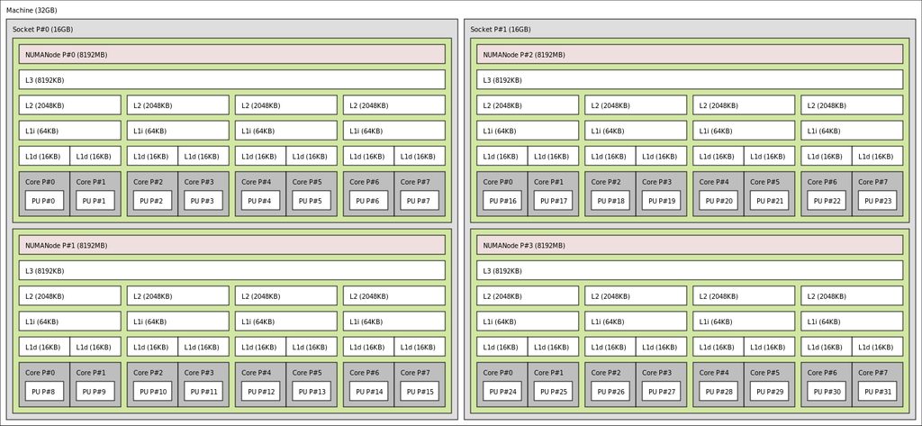

```python
Image("bulldozer.png")
```

1. *Heap*:
   - Large allocations.
   - Needs management.
2. *Stack*:
   - First in, Last out (“FILO”) type.
   - Short term memory

Memory allocation in the heap is managed by functions such:

- C: `malloc`, `calloc`, `free` or `_mm_malloc` (or masked by some higher level interface).
- C++: new, delete.
- Fortran: ALLOCATE.

If available, a pointer to memory reserved is delivered by the OS.

Programs often re-use nearby memory locations:

- Temporal locality: probably we will need again soon data from a location
- Spatial locality: nearby addresses likely to be needed soon

That's why we have caches.

Cache divided into cache lines: when memory is read into cache, a whole cache line is always read at the same time.  
Good if we have data locality: nearby memory accesses will be fast Typical cache line size: 64-128 bytes

How caches work:

**Direct-mapped cache**:

- Hash function maps to a single place for every unique address.

**Set associative cache**:

- Cache space is divided into n sets – Address is distributed modulo n – k-way set associative (k = 2...24).

**Fully associative cache**:

- Maps to any slot.

In practice, k-way set associative commonly used, e.g. L1d cache commonly 2-way set associative.

*Cache hit* *Cache miss*

Reasons for a miss:

- Compulsory: On the first access to a block.
- Capacity: When blocks are being discarded from cache because cache cannot contain all blocks.
- Conflict: In set associative or direct mapped strategies, conflict misses occur when several blocks are mapped to the same set or block frame

### Knowing your compiler

You have been told that GCC have several optimization levels (`-On`):

- -O0 : Reduce compilation time and make debugging produce the expected results. This is the default.
- -O or -O1 : Optimize. The compiler tries to reduce code size and execution time, without performing any optimizations that take a great deal of compilation time.
- -O2 Performs nearly all supported optimizations that do not involve a space-speed tradeoff. This is somewhat the *optmistic default* and it's used in many instances (Makefile, automated building processess).
- -Os : optimise for size

You can inspect what `-O1` should really means:

```python
gcc -O1 -Q --help=optimizers | grep enabled | wc -l
```

```
92
```

```python
gcc -O1 -Q --help=optimizers | grep enabled | grep inline
```

```
  -finline                    		[enabled]
  -finline-atomics            		[enabled]
  -finline-functions-called-once 	[enabled]
```

Why so many options? Because optimization is **very complex**: for each high level code snippet there **many** possible low level implementations. Developers and testers need a very fine grained control on what the compiler tries to do.

Two *very simple* source code level optimizations that a compiler will attempt are **common subexpression optimization** and **function inlining**.

**CSE** is about re-using computed values, especially for costly functions, by creating temporary variables:

```
a = cos(v)*(1+sin(u) + cos(w)*(1-sin(u))
```

evaluates `sin(u)` twice. However:

```
double temp = sin(u)
a = cos(v)*(1+temp)+cos(w)*(1-temp)
```

only does it once. The tradeoff between creating a new variable and evaluating a trigonometric functions is usually favorable.

**inlining** tries to reduce function call overhead for very small functions, such as:

```
int double_it(int x)
{
    return x+x;
}
for(int i=0; i<1E6; i++)
    a += double_it(i*3);
```

here, the cost of calling from memory the function `double_it` exceeds that of the computation. Again, the compiler will make use of temporary variables:

```
for(int i=0; i<1E6; i++)
{
    int temp = i*6
    a += temp
}
```

as you can see from above `-O1` involves function inlining under different conditions

Another option activated by `-O1` is `-fmove-loop-invariants` which will perform something like that (from Wikipedia):

```
for (int i = 0; i < n; i++) {
    x = y + z;
    a[i] = 6 * i + x * x;
}
```

```
x = y + z;
t1 = x * x;
for (int i = 0; i < n; i++)
    a[i] = 6 * i + t1;
```

While CSE reduces both the size and runtime of the code, inlining can achieve better performance at the cost of increased executable size. This is a *space time tradeoff*.  
Another common source code optimization that a compiler will attempt is **loop unrolling**:

```
for(int i=0; i<10; i++)
    a[i] = i+1;
```

the loop contains very few iterations and there is a overhead for managing the loop. The compiler then does:

```
a[0] = 1;
a[1] = 2;
...
a[9] = 10;
```

even if for a human this would less readable.

Use the `const` keyword to tell the compiler that the a value is read only.  
Allows compiler to optimize more because the compiler knows more.  
Using `const` also helps avoid programming errors, like modifying something by mistake.

Many source level optimizations, automatic or not, aims at:

- reduce the number of operations
- reduce their mathematical complexity
- increase the data locality of operations. This is perhaps the important thing

Automatic optimizations may be enhanced or inhibited by good coding even if nowadays we don't need to CSE by yourself

After source level optimizations, the compiler will deal the way to combine single instructions in different order (*scheduling*) or in parallel (*pipelining*).

Let's see what changes between `-O0` and `-O1`.

```python
%%writefile fibonacci.c
#include <stdio.h>
#include <stdlib.h>

void fib(unsigned *seq, unsigned position)
{
    seq[position] = seq[position-1]+seq[position-2];
    //return seq[position];
}

int main(int argc, char **argv)
{
    const unsigned L = argv[1] != NULL ? atoi(argv[1]) : 1E8;
    unsigned  *F = calloc(L,sizeof(unsigned));

    F[0] = 0;
    F[1] = 1;

    if(L>1)
        for (unsigned i = 2; i <= L; i++)
        {
            fib(F,i);
        }

  return F[L];
}
```

```
Writing fibonacci.c
```

```python
gcc -std=c99 -Wall -O0 -o fibonacci_O0.exe fibonacci.c -lm
```

```python
gcc -std=c99 -Wall -O1 -o fibonacci_O1.exe fibonacci.c -lm
```

```python
!ls -l| grep fib
```

```
-rw-r--r-- 1 g.mancini g.mancini     464 Jun 13 14:08 fibonacci.c
-rwxr-xr-x 1 g.mancini g.mancini 1031658 Jun 13 14:08 fibonacci_O0.exe
-rwxr-xr-x 1 g.mancini g.mancini 1031533 Jun 13 14:08 fibonacci_O1.exe
```

What about performance?

```python
!time ./fibonacci_O0.exe
```

```
real	0m0.766s
user	0m0.676s
sys	0m0.090s
```

```python
!time ./fibonacci_O1.exe
```

```
real	0m0.280s
user	0m0.220s
sys	0m0.059s
```

What appens with `-O2`?

```python
gcc -std=c99 -Wall -O2 -lm -o fibonacci_O2.exe fibonacci.c
```

```python
!ls -l fibonacci_O2.exe
```

```
-rwxr-xr-x 1 g.mancini g.mancini 1031533 Jun 13 14:08 fibonacci_O2.exe
```

```python
%%timeit
%%bash
./fibonacci_O2.exe
```

```
1 loop, best of 3: 257 ms per loop
```

What if you want to get an estimate on how much time is spent in some part of the code?  
Quick and dirty: `omp_get_wtime()`

```python
%%writefile fibonacci.c
#include <stdio.h>
#include <stdlib.h>
#include <omp.h>

void fib(unsigned *seq, unsigned position)
{
    seq[position] = seq[position-1]+seq[position-2];
    //return seq[position];
}

int main(int argc, char **argv)
{
    const unsigned L = argv[1] != NULL ? atoi(argv[1]) : 1E8;
    unsigned  *F = calloc(L,sizeof(unsigned));

    F[0] = 0;
    F[1] = 1;

    if(L>1)
    {
        double t0 = omp_get_wtime();
        for (unsigned i = 2; i <= L; i++)
        {
            fib(F,i);
        }
        printf("spent in loop %f\n",omp_get_wtime()-t0);
    }
  return F[L];
}
```

```
Overwriting fibonacci.c
```

```python
gcc -std=c99 -Wall -O2 -lm -fopenmp -o fibonacci.exe fibonacci.c
```

```python
%%bash
./fibonacci.exe
```

```
spent in loop 0.250892
```

For more information, have look at this little pearl:

```
An Introduction to GCC
by Brian J. Gough, foreword by Richard M. Stallman
ISBN 0-9541617-9-3
```

[figure not shown]

```python
Image("gough_stallman.jpg")
```

### Exercises

Consider the following:

$$ A^{nxn} = A^{nxn} + B^{nxn}*C^{nxn}$$

a naive C implementation may look like that:

```python
%%writefile matmul_dot.c
void matmul(int **a, int **b, int **c, int dim)
{
    for (int i = 0;i < dim; i++)
        for (int j = 0; j < dim; j++)
            for (int k = 0;k < dim; k++)
                a[i][j] += b[i][k] * c[k][j];
}
```

```
Writing matmul_dot.c
```

```python
%%writefile matmul_test.c
#include "matmul_test.h"

int main(int argc, char **argv)
{
    int n = argv[1] != NULL ? atoi(argv[1]) : 1000;
    int high = argv[1] != NULL ? atoi(argv[2]) : 100;

    srand(time(0));
    //in practice, do not forget to check for NULL
    int **A = malloc(n * sizeof(int*));
    for(int i = 0; i < n; i++)
        A[i] = malloc(n * sizeof(int));

    int **B = malloc(n * sizeof(int*));
    for(int i = 0; i < n; i++)
        B[i] = malloc(n * sizeof(int));

    int **C = malloc(n * sizeof(int*));
    for(int i = 0; i < n; i++)
        C[i] = malloc(n * sizeof(int));

    matset(A,n,high);
    matset(B,n,high);
    matset(C,n,high);
    if(n == 3)
    {
        matprint(A,n);
        matprint(B,n);
        matprint(C,n);
    }

    matmul(A,B,C,n);

    if(n == 3)
        matprint(A,n);
    return 0;
}
```

```
Writing matmul_test.c
```

```python
%%writefile matset.c
#include "matmul_test.h"

void matset(int **a, int dim, int high)
{

    for (int i = 0; i < dim; i++)
        for(int j = 0; j < dim; j++)
                a[i][j] = rand() % high+1;
}
```

```
Writing matset.c
```

```python
%%writefile matprint.c
#include "matmul_test.h"

void matprint(int **a, int dim)
{
    for(int i=0; i < dim; i++)
            printf("%d %d %d\n",a[i][0],a[i][1],a[i][2]);
}
```

```
Writing matprint.c
```

```python
%%writefile matmul_test.h
#include <stdio.h>
#include <stdlib.h>
#include <time.h>

void matset(int **a, int dim, int high);
void matmul(int **a, int **b, int **c, int dim);
void matprint(int **a, int dim);
```

```
Overwriting matmul_test.h
```

```python
gcc -std=c99 -Wall -O0 -o matmul.exe matmul_test.c matmul_dot.c matset.c matprint.c
```

```python
%%bash
./matmul.exe 3 10 | tee log
```

```
10 4 1
2 7 3
10 9 9
5 2 10
8 7 10
3 6 10
7 10 9
1 5 6
9 8 3
137 144 88
155 202 147
127 149 102
```

```python
X = np.loadtxt("log")
a = X[:3,:]
b = X[3:6,:]
c = X[6:9,:]
a+np.dot(b,c)
```

```
array([[ 137.,  144.,   88.],
       [ 155.,  202.,  147.],
       [ 127.,  149.,  102.]])
```

1. What is the slower part of the code?
2. Try to apply compiler optimization. How much speedup you get?
3. Allocation: is that the only way of allocating a matrix and get references to `A[i][j]`?
4. It is possible to modify the *matrix multiplication* function to get even more speedup?

```python
Image("gears.png")
```

[output not shown]

### Solutions

#### part 1

```python
%%writefile matmul_test.c
#include "matmul_test.h"
#include <omp.h>

int main(int argc, char **argv)
{
    int n = argv[1] != NULL ? atoi(argv[1]) : 1000;
    int high = argv[1] != NULL ? atoi(argv[2]) : 100;

    srand(time(0));
    //in practice, do not forget to check for NULL

    double t0 = omp_get_wtime();
    int **A = malloc(n * sizeof(int*));
    for(int i = 0; i < n; i++)
        A[i] = malloc(n * sizeof(int));

    int **B = malloc(n * sizeof(int*));
    for(int i = 0; i < n; i++)
        B[i] = malloc(n * sizeof(int));

    int **C = malloc(n * sizeof(int*));
    for(int i = 0; i < n; i++)
        C[i] = malloc(n * sizeof(int));

    double t1 = omp_get_wtime();
    printf("spent in allocation %f\n",t1-t0);

    matset(A,n,high);
    matset(B,n,high);
    matset(C,n,high);
    double t2 = omp_get_wtime();
    printf("spent in set %f\n",t2-t1);

    if(n <= 3)
    {
        matprint(A,n);
        matprint(B,n);
        matprint(C,n);
    }

    matmul(A,B,C,n);
    double t3 = omp_get_wtime();
    printf("spent in multiplication %f\n",t3-t2);

    if(n <= 3)
        matprint(A,n);
    return 0;
}
```

```
Overwriting matmul_test.c
```

```python
gcc -std=c99 -Wall -O0 -lm -fopenmp -o matmul.exe matmul_test.c matmul_dot.c matset.c matprint.c
```

```python
%%bash
./matmul.exe
```

```
spent in allocation 0.003397
spent in set 0.034908
spent in multiplication 8.559885
```

```python
%%capture mm_o0
!time ./matmul.exe
```

#### part 2

**-O1**

```python
gcc -std=c99 -Wall -O1 -fopenmp -o matmul.exe matmul_test.c matmul_dot.c matset.c matprint.c
```

```python
%%capture mm_o1
!time ./matmul.exe
```

**-O2**

```python
gcc -std=c99 -Wall -O2 -fopenmp -o matmul.exe matmul_test.c matmul_dot.c matset.c matprint.c
```

```python
%%capture mm_o2
!time ./matmul.exe
```

**-O3**

```python
gcc -std=c99 -Wall -O3 -fopenmp -o matmul.exe matmul_test.c matmul_dot.c matset.c matprint.c
```

```python
%%capture mm_o3
!time ./matmul.exe
```

**Results**

```python
for i,j in enumerate((mm_o0,mm_o1,mm_o2,mm_o3)):
    time = j.stdout.split()[11]
    print("Opt. level ",i," spent ",time," s in multiplication")
```

```
Opt. level  0  spent  8.536413  s in multiplication
Opt. level  1  spent  6.502253  s in multiplication
Opt. level  2  spent  6.959907  s in multiplication
Opt. level  3  spent  7.025835  s in multiplication
```

#### part 3

```python
%%writefile matmul_test.c
#include "matmul_test.h"
#include <omp.h>

int main(int argc, char **argv)
{
    int n = argv[1] != NULL ? atoi(argv[1]) : 1000;
    int high = argv[1] != NULL ? atoi(argv[2]) : 100;

    srand(time(0));
    //in practice, do not forget to check for NULL

    double t0 = omp_get_wtime();
    int **A = malloc(n * sizeof(int*));
    A[0] = malloc(n * n * sizeof(int));
    for(int i = 1; i < n; i++)
        A[i] = A[0] + i*n;

    int **B = malloc(n * sizeof(int*));
    B[0] = malloc(n * n * sizeof(int));
    for(int i = 1; i < n; i++)
        B[i] = B[0] + i*n;

    int **C = malloc(n * sizeof(int*));
    C[0] = malloc(n * n * sizeof(int));
    for(int i = 1; i < n; i++)
        C[i] = C[0] + i*n;

    double t1 = omp_get_wtime();
    printf("spent in allocation %f\n",t1-t0);

    matset(A,n,high);
    matset(B,n,high);
    matset(C,n,high);
    double t2 = omp_get_wtime();
    printf("spent in set %f\n",t2-t1);

    if(n == 3)
    {
        matprint(A,n);
        matprint(B,n);
        matprint(C,n);
    }

    matmul(A,B,C,n);
    double t3 = omp_get_wtime();
    printf("spent in multiplication %f\n",t3-t2);

    if(n == 3)
        matprint(A,n);
    return 0;
}
```

```
Overwriting matmul_test.c
```

```python
gcc -std=c99 -Wall -O1 -fopenmp -o matmul.exe matmul_test.c matmul_dot.c matset.c matprint.c
```

```python
%%capture mm_o0_2
!time ./matmul.exe
```

**-O1**

```python
gcc -std=c99 -Wall -O1 -fopenmp -o matmul.exe matmul_test.c matmul_dot.c matset.c matprint.c
```

```python
%%capture mm_o1_2
!time ./matmul.exe
```

**-O2**

```python
gcc -std=c99 -Wall -O2 -fopenmp -o matmul.exe matmul_test.c matmul_dot.c matset.c matprint.c
```

```python
%%capture mm_o2_2
!time ./matmul.exe
```

**-O3**

```python
gcc -std=c99 -Wall -O3 -fopenmp -o matmul.exe matmul_test.c matmul_dot.c matset.c matprint.c
```

```python
%%capture mm_o3_2
!time ./matmul.exe
```

**Results**

```python
for i,j in enumerate((mm_o0_2,mm_o1_2,mm_o2_2,mm_o3_2)):
    time = j.stdout.split()[11]
    print("Opt. level ",i," spent ",time," s in multiplication")
```

[output not shown]

#### part 4

We spent a lot of time in class 1 speaking about caches and memory bottlenecks.  
In the way `matmul` is written, each element of A is the dot product of a row of B and column of C.  
If we swap the loops on `j` and `k` then, for each row of A (loaded in cache), we use one element in B and the same row in C:

```python
%%writefile matmul_blas.c
void matmul(int **a, int **b, int **c, int dim)
{
    for (int i = 0;i < dim; i++)
        for (int k = 0;k < dim; k++)
            for (int j = 0; j < dim; j++)
                a[i][j] += b[i][k] * c[k][j];
}
```

```
Writing matmul_blas.c
```

**-O0**

```python
gcc -std=c99 -Wall -O0 -fopenmp -o matmul.exe matmul_test.c matmul_blas.c matset.c matprint.c
```

```python
%%capture mm_o0_blas
!time ./matmul.exe
```

**-O1**

```python
gcc -std=c99 -Wall -O1 -fopenmp -o matmul.exe matmul_test.c matmul_blas.c matset.c matprint.c
```

```python
%%capture mm_o1_blas
!time ./matmul.exe
```

**-O2**

```python
gcc -std=c99 -Wall -O2 -fopenmp -o matmul.exe matmul_test.c matmul_blas.c matset.c matprint.c
```

```python
%%capture mm_o2_blas
!time ./matmul.exe
```

**-O3**

```python
gcc -std=c99 -Wall -O3 -fopenmp -o matmul.exe matmul_test.c matmul_blas.c matset.c matprint.c
```

```python
%%capture mm_o3_blas
!time ./matmul.exe
```

**Results**

```python
v = list()
for i,j in enumerate((mm_o0,mm_o1,mm_o2,mm_o3)):
    time = j.stdout.split()[11]
    v.append(float(time))
    print("Opt. level ",i," spent ",time," s in multiplication")

for i,j in enumerate((mm_o0_2,mm_o1_2,mm_o2_2,mm_o3_2)):
    time = j.stdout.split()[11]
    v.append(float(time))
    print("Opt. level ",i," spent ",time," s in multiplication")

for i,j in enumerate((mm_o0_blas,mm_o1_blas,mm_o2_blas,mm_o3_blas)):
    time = j.stdout.split()[11]
    v.append(float(time))
    print("Opt. level ",i," spent ",time," s in multiplication")
```

```
Opt. level  0  spent  8.536413  s in multiplication
Opt. level  1  spent  6.502253  s in multiplication
Opt. level  2  spent  6.959907  s in multiplication
Opt. level  3  spent  7.025835  s in multiplication
Opt. level  0  spent  2.995430  s in multiplication
Opt. level  1  spent  2.977991  s in multiplication
Opt. level  2  spent  2.037096  s in multiplication
Opt. level  3  spent  2.028622  s in multiplication
Opt. level  0  spent  6.766699  s in multiplication
Opt. level  1  spent  1.949958  s in multiplication
Opt. level  2  spent  1.262805  s in multiplication
Opt. level  3  spent  0.459469  s in multiplication
```

```python
v[0]/v[-1]
```

```
18.578866038840488
```

This is an example of *loop interchange* and some compilers (e. g. Intel) can sometimes do that.  
*It's not only faster by himself but leads to improved optimization*

similar tricks (and more complex ones) are used in linear algebra libraries such as:

- Eigen
- BLAS,LAPACK
- ATLAS

and many others.

the success of Python in scientific computing is based on the performance of Numpy/Scipy which in turn are smart interfaces which exploit data locality and low level libraries

not too bad a speedup for half a lecture ...

**Take home message**

Multidimensional arrays are the ubiquitous data type in scientific computing.  
Hence data access is a crucial topic: mapping between cache line (1D) and ND data structures has to maximise spatial and temporal locality.

### (GNU) Makefiles

Optimization, warnings, path and other options make very difficult to compile large projects from the command line. That's why there a lot of tools of automated/assisted build.

E. g. And IDE like Qtcreator creates template and project (*.pro) files

some other tools for automatic creation of customized enviroment are:

- CMake
- Scons
- GNU Autotools

and many others

The simplest (but not most efficent) tool is the humble `Makefile` containing shell commands to run the compilation and linking processes.  
Make keeps track of the last time files (normally object files) were updated and only updates those files which are required (ones containing changes) to keep the sourcefile up-to-date.

The makefile contains a list of **rules**. These tell the system what commands you want to be executed.  
The rules, which must begin in column 1, are in two parts. The first line is called a **dependency line** and the subsequent line(s) are called actions or commands. The action line(s) must be indented with a tab.

```
RULE:    DEPENDENCY LINE
[tab]ACTION LINE(S)
```

The dependency line is made of two parts. The first part (before the colon) are target files and the second part (after the colon) are called source files. It is called a dependency line because the first part depends on the second part. Multiple target files must be separated by a space. Multiple source files must also be separated by a space.

```
DEPENDENCY LINE: TARGET FILES:    SOURCE FILES
```

```python
%%writefile Makefile_example
CC=/usr/local/gcc-7.3.0/bin/gcc
CFLAGS= -std=c99 -Wall -fopenmp
OFLAGS= -O2
LDFLAGS=-lm -fopenmp -L/usr/local/gcc-7.3.0/lib64
CPPFLAGS=-I/usr/local/gcc-7.3.0/include
SHELL   = /bin/sh
OBJECTS  = matmul_test.o matset.o matmul_blas.o matprint.o
TARGET   = matmul.exe

ifneq ($(opt),)
	CFLAGS  += $(OFLAGS)
endif

# first target: run by default if no target given
all: $(TARGET)

# dependencies of TARGET took from variable name
# give dependencies then recipe after tab
$(TARGET): $(OBJECTS)
	$(CC) -o $(TARGET) $(OBJECTS) $(LDFLAGS)

#pattern rule: %.o matches any .o file (target) and %.c any .c file (prerequisite);
# target and prerequisite must match
# $< and $@ are automatic variables for prerequisites and targets
%.o : %.c
	$(CC) -c $(CFLAGS) $(CPPFLAGS) $< -o $@

#phony targets: do not create files; run every time a target is updated
# unless in PHONY list
.PHONY: clean
clean:
	rm -f $(TARGET) $(OBJECTS) *.s
```

```
Overwriting Makefile_example
```

```python
!make -f Makefile_example clean
```

```
rm -f matmul.exe matmul_test.o matset.o matmul_blas.o matprint.o *.s
```

```python
!make -f Makefile_example
```

```
/usr/local/gcc-7.3.0/bin/gcc -c -std=c99 -Wall -fopenmp -I/usr/local/gcc-7.3.0/include matmul_test.c -o matmul_test.o
/usr/local/gcc-7.3.0/bin/gcc -c -std=c99 -Wall -fopenmp -I/usr/local/gcc-7.3.0/include matset.c -o matset.o
/usr/local/gcc-7.3.0/bin/gcc -c -std=c99 -Wall -fopenmp -I/usr/local/gcc-7.3.0/include matmul_blas.c -o matmul_blas.o
/usr/local/gcc-7.3.0/bin/gcc -c -std=c99 -Wall -fopenmp -I/usr/local/gcc-7.3.0/include matprint.c -o matprint.o
/usr/local/gcc-7.3.0/bin/gcc -o matmul.exe matmul_test.o matset.o matmul_blas.o matprint.o -lm -fopenmp -L/usr/local/gcc-7.3.0/lib64
```

```python
!time ./matmul.exe
```

```
spent in allocation 0.000058
spent in set 0.038211
spent in multiplication 6.787085

real	0m6.827s
user	0m6.829s
sys	0m0.001s
```

targets can be passed to select building modes:

```python
!make clean -f Makefile_example && make -f Makefile_example opt=1
```

```
rm -f matmul.exe matmul_test.o matset.o matmul_blas.o matprint.o *.s
/usr/local/gcc-7.3.0/bin/gcc -c -std=c99 -Wall -fopenmp -O2 -I/usr/local/gcc-7.3.0/include matmul_test.c -o matmul_test.o
/usr/local/gcc-7.3.0/bin/gcc -c -std=c99 -Wall -fopenmp -O2 -I/usr/local/gcc-7.3.0/include matset.c -o matset.o
/usr/local/gcc-7.3.0/bin/gcc -c -std=c99 -Wall -fopenmp -O2 -I/usr/local/gcc-7.3.0/include matmul_blas.c -o matmul_blas.o
/usr/local/gcc-7.3.0/bin/gcc -c -std=c99 -Wall -fopenmp -O2 -I/usr/local/gcc-7.3.0/include matprint.c -o matprint.o
/usr/local/gcc-7.3.0/bin/gcc -o matmul.exe matmul_test.o matset.o matmul_blas.o matprint.o -lm -fopenmp -L/usr/local/gcc-7.3.0/lib64
```

```python
%%bash
./matmul.exe
```

```
spent in allocation 0.000054
spent in set 0.032834
spent in multiplication 1.262099
```

# 2 - Vectorization

## What is vectorization?

- Perform one operation on multiple elements of a vector
- Chunk-wise processing instead of element wise
- Can lower computational cost
- A form of **Single Instruction Multiple Data** (SIMD) parallelism

basically, in addition to adding cores, I also add more FPU units per core

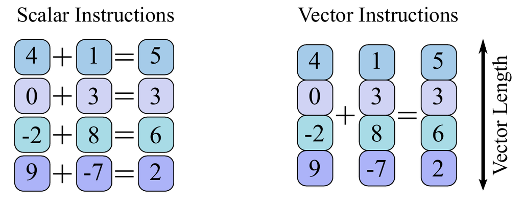

```python
Image("vector.png")
```

So I want to apply the same instruction on multiple elements: how many of them?  
Depends on the CPU model:

```python
!cat /proc/cpuinfo |awk '/flags/{a=$0}END{print a}'
```

```
flags		: fpu vme de pse tsc msr pae mce cx8 apic sep mtrr pge mca cmov pat pse36 clflush dts acpi mmx fxsr sse sse2 ss ht tm pbe syscall nx pdpe1gb rdtscp lm constant_tsc arch_perfmon pebs bts rep_good nopl xtopology nonstop_tsc aperfmperf pni pclmulqdq dtes64 monitor ds_cpl vmx smx est tm2 ssse3 cx…
```

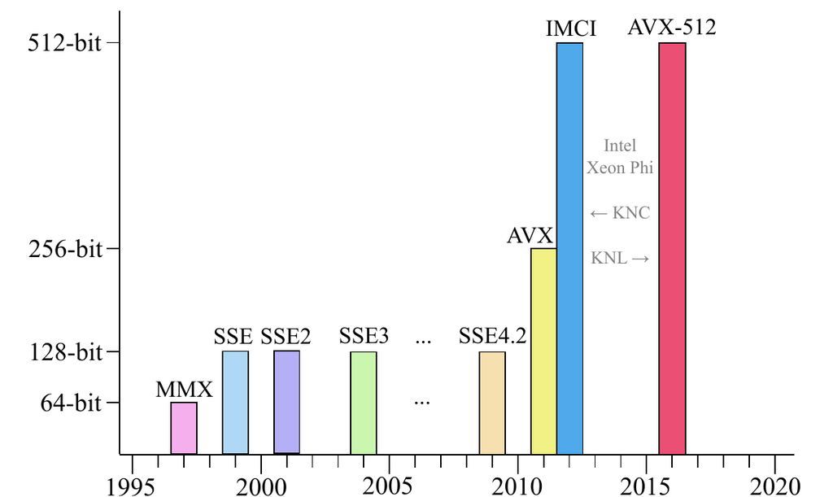

```python
Image("inst_set.png")
```

SIMD extensions theoretical speedup:

| in. set | size | single sp. | double sp. |
| --- | --- | --- | --- |
| MMX | 64 | 2x | -- |
| SSE, AVX-128 | 128 | 4x | 2x |
| AVX-256 | 256 | 8x | 4x |
| MIC, AVX-512 | 512 | 16x | 8x |

AVX-512 is supported by Skylake onward (Xeon and Core*iX*).  
MIC is supported by the XeonPhi coprocessor family (see here):

[figure not shown]

```python
Image("phi_photo.jpeg")
```

Possible bottlenecks?

... you guess it ...

Memory bandwidth, Poor cache utilization, alignment, memory latency

Think of vectorization in terms of loop unrolling:

```
for(int i = 0;i < max; i++)
    A[i] = B[i] + C[i]*D[i]
```

```
for(int i = 0;i < max; i=i+vsize)
    A[i+0] = B[i+0] + C[i+0]*D[i+0]
    A[i+1] = B[i+1] + C[i+1]*D[i+1]
    A[i+2] = B[i+2] + C[i+2]*D[i+2]
    ...
    A[i+vsize-1] = B[i+vsize-1] + C[i+vsize-1]*D[i+vsize-1]
```

### How to tap into vectorization?

1. SIMD Instructions are assembly, use assembly.
2. Modify the code, use intrisics such as `__attribute__ ((vector_size (16)))`
3. Is an optimization, let the compiler do it
4. Use vectorized libraries (Intel MKL, Eigen, ACML)

#### Where we should focus?

1. for/do loops
2. remove obstacles to (auto)vectorization
3. improve data access patterns
4. no *pointer aliasing*

always same story

#### Good vector loops candidates

- Iterations known before loop starts
- No `break`/`continue`
- Single control flow (no `if` or `switch`); use masks if possible
- Innermost loop
- No complicated function calls (`pow()`, `sin()`, ... are ok)
- Inlining

#### Intrisics

```
double A[8], B[8];
__m512d A_v = _mm512_load_pd(A);
__m512d B_v = _mm512_load_pd(B);
A_v = _mm512_add_pd(A_v,B_v);
_mm512_store_pd(A, A_v);
```

#### Pointer aliasing

From Wikipedia: In computer programming, aliasing refers to the situation where the same memory location can be accessed using different names.

```
int A[10];
int *B = A;

int a;
int *b = &a;
```

```python
%%writefile alias.c
void foo(int *a, int *b, int *c)
{
    *a = 1492;
    *b = 1789;
    *c = *a;
}

int main()
{
    int *a, *b, *c;
    foo(a,b,c);
}
```

```
Writing alias.c
```

the gcc option `-S` allow to save the assembly code:

```python
gcc -O1 -S alias.c
```

```python
!cat alias.s |grep movl
```

```
	movl	$1492, (%rdi)
	movl	$1789, (%rsi)
	movl	(%rdi), %eax
	movl	%eax, (%rdx)
	movl	$0, %eax
```

`movl %edx, (%rax)` means copy the content of a register file unto another

for more information on x86 assembly see [#here](http://www.cs.virginia.edu/~evans/cs216/guides/x86.html)

the `restrict` keyword tells the compiler that pointers do not point to the same memory:

```python
%%writefile alias.c
void foo(int *__restrict a, int *b, int *__restrict c)
{
    *a = 1492;
    *b = 1789;
    *c = *a;
}

int main()
{
    int *a, *b, *c;
    foo(a,b,c);
}
```

```
Overwriting alias.c
```

```python
gcc -O1 -S alias.c
```

```python
!cat alias.s |grep movl
```

```
	movl	$1492, (%rdi)
	movl	$1789, (%rsi)
	movl	$1492, (%rdx)
	movl	$0, %eax
```

What about:

```
void AmbiguousFunction(int n, int *a, int *b)
{
    for (int i = 0; i < n; i++)
    a[i] = b[i];
}
```

### Automatic vectorization with GCC

- `-ftree-vectorize` activates vectorization as a form of optimization
- `-fopt-info-vec` report optimization success
- `-fopt-invo-vec-missed` optimization failure

NB vectorization requires `-O2` and must be explicitly set

- `-march=native` architecture dependent flags
- `-falign-functions=32`, `-falign-loops=32` align the address of functions / loops to be a multiple of 32 bytes

NB alignment of data is presented as beneficial in some source but this is debated (see here) for example.  
Personally I was unable to show its effectiveness with my setup and I will skip discussing it.  
My guess is that fairly modern compilers and (x86-64) CPUs handle it automatically.

SIMD CPU instructions are activated by:

- `-mmmx`, `-msse`, `-msse2`,`-msse3`,`-msse4`,`-msse4.2`, `-mavx`, `-mavx512`  
  and disabled by:
- `-mno-sse` ...

Automatic detection of the hardware is fortunately done by:

- `-march=native`

```python
!gcc -march=native -Q --help=target|grep sse
```

```
  -mno-sse4                   		[disabled]
  -msse                       		[enabled]
  -msse2                      		[enabled]
  -msse2avx                   		[disabled]
  -msse3                      		[enabled]
  -msse4                      		[enabled]
  -msse4.1                    		[enabled]
  -msse4.2                    		[enabled]
  -msse4a                     		[disabled]
  -msse5
  -msseregparm                		[disabled]
  -mssse3                     		[enabled]
  Known assembler dialects (for use with the -masm-dialect= option):
    387 387+sse 387,sse both sse sse+387 sse,387
```

```python
!gcc -mavx -march=native -Q --help=target|grep avx
```

```
  -mavx                       		[enabled]
  -mavx2                      		[disabled]
  -mavx256-split-unaligned-load 	[disabled]
  -mavx256-split-unaligned-store 	[disabled]
  -mprefer-avx128             		[disabled]
  -msse2avx                   		[disabled]
```

you should check the instruction supported by your CPU and your environment to know what is enabled by default (AVX and SSE above) and what you can enable (AVX2)

```python
!cat /proc/cpuinfo |awk '/flags/{a=$0}END{print a}'
```

```
flags		: fpu vme de pse tsc msr pae mce cx8 apic sep mtrr pge mca cmov pat pse36 clflush dts acpi mmx fxsr sse sse2 ss ht tm pbe syscall nx pdpe1gb rdtscp lm constant_tsc arch_perfmon pebs bts rep_good nopl xtopology nonstop_tsc aperfmperf pni pclmulqdq dtes64 monitor ds_cpl vmx smx est tm2 ssse3 cx…
```

GCC vectorization capabilities are limited as compared with that of the Intel compiler, both in terms of functionality and performance.  
For instance, using *pragmas* Intel allows to vectorize outer loops also.  
Colfax research has some nice information on vectorization with Intel here and here.

```python
%%writefile loop.c
#include <stdio.h>
#include <stdlib.h>
#include <omp.h>

void set(int *a,int size)
{
    for(int i = 0; i < size; i++)
        a[i] = i;
}

void sum(int *a, int *b, int size)
{
    for(int i=0; i < size; i++)
        a[i] += b[i];
}

int main()
{

    const int size = 1 << 16;
    int *A = calloc(sizeof(int),size);
    int *B = calloc(sizeof(int),size);

    set(A,size);
    set(B,size);

    double t0 = omp_get_wtime();
    sum(A,B,size);
    int last = A[size-1]/2;
    printf("%g %d\n",omp_get_wtime()-t0,last);
}
```

```
Writing loop.c
```

```python
gcc -O2 -Wall -std=c99 -lm -ftree-vectorize -fopenmp -S loop.c
```

```python
!cat loop.s |grep vmov
```

```python
gcc -O2 -Wall -std=c99 -lm -ftree-vectorize -fopenmp -mavx2 -S loop.c
```

```python
!cat loop.s |grep vmov
```

```
	vmovdqa	.LC0(%rip), %ymm0
	vmovdqa	.LC1(%rip), %ymm1
	vmovups	%xmm0, (%rax)
	vmovdqu	(%rdi,%rax), %xmm0
	vmovdqu	(%rsi,%rax), %xmm0
	vmovups	%xmm0, (%rdi,%rax)
	vmovdqa	.LC0(%rip), %ymm0
	vmovdqa	.LC1(%rip), %ymm2
	vmovdqa	%ymm0, %ymm1
	vmovups	%xmm1, (%rdx)
	vmovups	%xmm0, (%rdx)
	vmovsd	%xmm0, -56(%rbp)
	vmovdqu	(%r12,%rdx), %xmm0
	vmovdqu	(%rbx,%rdx), %xmm0
	vmovups	%xmm0, (%rbx,%rdx)
```

where "move a quadword integer" (`movq`) becomes "use AVX" (`vmov`) to "move a double aligned quadword integer" (`movdqa`)

Let' see how it works:

**non vectorized**

```python
gcc -O0 -Wall -std=c99 -fopenmp -o loop.exe loop.c
```

```python
!./loop.exe
```

```
0.000274256 65535
```

```python
gcc -O2 -Wall -std=c99 -fopenmp -o loop.exe loop.c
```

```python
!./loop.exe
```

```
6.29439e-05 65535
```

**vectorized**

```python
gcc -O2 -ftree-vectorize -march=native -mssse3 -Wall -std=c99 -fopenmp -fopt-info-vec-optimized -o loop.exe loop.c
```

```
loop.c:7:5: note: loop vectorized
loop.c:13:5: note: loop vectorized
loop.c:13:5: note: loop versioned for vectorization because of possible aliasing
loop.c:13:5: note: loop vectorized
loop.c:7:5: note: loop vectorized
loop.c:7:5: note: loop vectorized
```

```python
!./loop.exe
```

```
2.5501e-05 65535
```

What about restrict?

```python
%%writefile loop.c
#include <stdio.h>
#include <stdlib.h>
#include <omp.h>

void set(int *a,int size)
{
    for(int i = 0; i < size; i++)
        a[i] = i;
}

void sum(int *__restrict a, int *__restrict b, int size)
{
    for(int i=0; i < size; i++)
        a[i] += b[i];
}

int main()
{

    const int size = 1 << 16;
    int *A = calloc(sizeof(int),size);
    int *B = calloc(sizeof(int),size);

    set(A,size);
    set(B,size);

    double t0 = omp_get_wtime();
    sum(A,B,size);
    int last = A[size-1]/2;
    printf("%g %d\n",omp_get_wtime()-t0,last);
}
```

```
Overwriting loop.c
```

```python
gcc -O2 -ftree-vectorize -mssse3 -march=native -Wall -std=c99 -lm -fopenmp -fopt-info-vec-optimized -o loop.exe loop.c
```

```
loop.c:7:5: note: loop vectorized
loop.c:13:5: note: loop vectorized
loop.c:13:5: note: loop vectorized
loop.c:7:5: note: loop vectorized
loop.c:7:5: note: loop vectorized
```

```python
!./loop.exe
```

```
2.56668e-05 65535
```

See also:

- CERN link on vectorization
- GCC project on autovectorization (old)
- here
- Intel Intrisic Guide

If you use Fortran have a look here

### Exercises

1. Consider again the matrix multiplication code. We have several versions that we may want to compare. Can you use a Makefile to make life simpler? Does it improve with vectorization?

```python
Image("gears.png")
```

[output not shown]

#### part 1 (very simple)

```python
%%writefile Makefile
CC=/usr/local/gcc-7.3.0/bin/gcc
CFLAGS= -std=c99 -Wall -fopenmp
OFLAGS= -O3
VFLAGS= -ftree-vectorize -march=native -msse3 -fopt-info-vec-optimized
LDFLAGS=-lm -fopenmp -L/usr/local/gcc-7.3.0/lib64
CPPFLAGS=-I/usr/local/gcc-7.3.0/include
SHELL   = /bin/sh
OBJECTS  = matmul_test.o matset.o matprint.o

ifneq ($(vec),)
	CFLAGS  += $(OFLAGS) $(VFLAGS)
endif

ifneq ($(opt),)
	CFLAGS  += $(OFLAGS)
endif

all: matmul.exe

matmul.exe: $(OBJECTS) matmul_blas.o
	$(CC) -o matmul.exe $(OBJECTS) matmul_blas.o $(LDFLAGS)

dot: $(OBJECTS) matmul_dot.o
	$(CC) -o matmul.exe $(OBJECTS) matmul_dot.o $(LDFLAGS)

%.o : %.c
	$(CC) -c $(CFLAGS) $(CPPFLAGS) $< -o $@

.PHONY: clean
clean:
	rm -f matmul.exe *.o *.s
```

```
Overwriting Makefile
```

```python
%%writefile matmul_test.c
#include "matmul_test.h"
#include <omp.h>

int main(int argc, char **argv)
{
    int n = argv[1] != NULL ? atoi(argv[1]) : 1000;
    int high = argv[1] != NULL ? atoi(argv[2]) : 100;
    srand(time(0));
    //in practice, do not forget to check for NULL

    double t0 = omp_get_wtime();
    int *A = malloc(n * n * sizeof(int));
    int *B = malloc(n * n * sizeof(int));
    int *C = malloc(n * n * sizeof(int));

    double t1 = omp_get_wtime();
    printf("spent in allocation %f\n",t1-t0);

    matset(A,n,high);
    matset(B,n,high);
    matset(C,n,high);
    double t2 = omp_get_wtime();
    printf("spent in set %f\n",t2-t1);

    matmul(A,B,C,n);
    double t3 = omp_get_wtime();
    printf("spent in multiplication %f\n",t3-t2);
}
```

```
Overwriting matmul_test.c
```

```python
%%writefile matset.c
#include "matmul_test.h"

void matset(int *X, int dim, int high)
{
    for (int i = 0;i < dim; i++)
        for(int j = 0; j < dim; j++)
                X[i*dim + j] = rand() % high;

}
```

```
Overwriting matset.c
```

```python
%%writefile matmul_test.h
#include <stdio.h>
#include <stdlib.h>
#include <time.h>
#include <omp.h>

void matset(int *X, int dim, int high);
void matmul(int *__restrict a, int *__restrict b, int *__restrict c, int dim);
```

```
Overwriting matmul_test.h
```

```python
%%writefile matmul_blas.c
void matmul(int *__restrict a, int *__restrict b, int *__restrict c, int dim)
{
    for (int i = 0;i < dim; i++)
        for (int k = 0;k < dim; k++)
        {
            int temp = b[i*dim + k];
            for (int j = 0; j < dim; j++)
                a[i*dim + j] += temp * c[k*dim + j];
        }
}
```

```
Overwriting matmul_blas.c
```

```python
!make clean && make vec=1
```

```
rm -f matmul.exe *.o *.s
/usr/local/gcc-7.3.0/bin/gcc -c -std=c99 -Wall -fopenmp -O3 -ftree-vectorize -march=native -msse3 -fopt-info-vec-optimized -I/usr/local/gcc-7.3.0/include matmul_test.c -o matmul_test.o
/usr/local/gcc-7.3.0/bin/gcc -c -std=c99 -Wall -fopenmp -O3 -ftree-vectorize -march=native -msse3 -fopt-info-vec-optimized -I/usr/local/gcc-7.3.0/include matset.c -o matset.o
/usr/local/gcc-7.3.0/bin/gcc -c -std=c99 -Wall -fopenmp -O3 -ftree-vectorize -march=native -msse3 -fopt-info-vec-optimized -I/usr/local/gcc-7.3.0/include matprint.c -o matprint.o
/usr/local/gcc-7.3.0/bin/gcc -c -std=c99 -Wall -fopenmp -O3 -ftree-vectorize -march=native -msse3 -fopt-info-vec-optimized -I/usr/local/gcc-7.3.0/include matmul_blas.c -o matmul_blas.o
matmul_blas.c:7:13: note: loop vectorized
/usr/local/gcc-7.3.0/bin/gcc -o matmul.exe matmul_test.o matset.o matprint.o matmul_blas.o -lm -fopenmp -L/usr/local/gcc-7.3.0/lib64
```

```python
%%bash
./matmul.exe
```

```
spent in allocation 0.000036
spent in set 0.033831
spent in multiplication 0.331292
```

### Finer control: pragmas

Limits on autovectorization:

- Data dependencies
- Function calls in loop block
- Complex control flow / conditional branches
- Loop not “countable”

OpenMP 4.0 offers support for a standard implementation of vector instructions using pragmas which are managed by the compiler. As an example, GCC supports many pragmas for different purposes. Some set of pragmas (such as those defined in the OpenMP standard) are supported by many compilers (see here).

In particular, it is possible to define pragmas to vectorize a specific loop construct, ignoring others:

```
\#pragma omp simd
 for-loop

!$omp simd
do-loop
!$omp end simd
```

```
void matmul(int *a, int *b, int *c,int n) {
    for (int i=0; i<n; i++)
        for (int k=0; k<n; k++)
            #pragma omp simd
                for (int k=0; k<n; k++)
                a[i][j] += b[i][k] * c[k][j];
```

SIMD pragmas are activated at `-O2` by specifying `-fopenmp-simd`:

```python
%%writefile loop_simd.c
void sum(int *a, int *b, int *c, int size)
{
    #pragma omp simd
    for(int i=1; i < size; i++)
        a[i] += b[i-1];

    for(int i=1; i < size; i++)
        a[i] += c[i];
}
```

```
Writing loop_simd.c
```

```python
gcc -Wall -std=c99 -O2 -fopt-info-vec-optimized -march=native -mssse3 -fopenmp-simd -c -o loop_simd.o loop_simd.c
```

```
loop_simd.c:5:14: note: loop vectorized
```

Additional settings in a pragma directive can be set with *clauses*:

- `safelen (length)`
  - Maximum number of iterations that can run concurrently without breaking a dependence
- `simdlen (length)`
  - Specify preferred length of SIMD registers used
- `linear (list[:linear-step])`
  - The variable’s value is in relationship with the iteration number: `x i = x orig + i * linear-step`
- `ivdep`
  - No vector dependence. Alternative to `__restrict`

#### Data sharing clauses

A particularly important category of clauses are those that perform *data sharing* between *vector lanes*.  
Consider the following snippet

```
#pragma omp simd
for(int i=0; i<n; i++)
    sum += a[i];
```

can we vectorize it? how?

one way would be to create copies of the`sum` variable and store partial sums (*promoting* the scalar to vector):

```
sum[2] = {0.;0.};
#pragma omp simd
for(int i=0; i<n; i=i+2)
    sum[0] += a[i];
    sum[1] += a[i+1];
```

and then collect the results (*reducing* again the vector to a scalar):

```
sum_final = sum[0] + sum[1]
```

This is such a common need that the *reduction* is supported (for simple operators) by the standard:

```
#pragma omp simd reduction(+:sum)
for(int i=0; i<n; i++)
    sum += a[i];
```

#### SIMD Function Vectorization

define, in one library, use somewhere esle

```
#pragma omp declare simd
float distsq(float x, float y)
{
    return (x - y) * (x - y);
}

void example()
{
    #pragma omp parallel for simd
    for (i=0; i<N; i++)
        d[i] = min(distsq(a[i], b[i]), c[i]);

}
```

Even for quite complex functions:

```
#pragma omp declare simd
float MyErfElemental(const float inx)
{
    const float x = fabsf(inx); // Absolute value (in each vector lane)
    const float p = 0.3275911f; // Constant parameter across vector lanes
    const float t = 1.0f/(1.0f+p*x); // Expression in each vector lanes
    const float l2e = 1.442695040f; // log2f(expf(1.0f))
    const float e = exp2f(-x*x*l2e); // Transcendental in each vector lane
    float res = -1.453152027f + 1.061405429f*t; // Computing a polynomial
    res = 1.421413741f + t*res; // in each vector lane
    res =-0.284496736f + t*res;
    res = 0.254829592f + t*res;
    res *= e;
    res = 1.0f - t*res; // Analytic approximation in each vector lane
    return copysignf(res, inx); // Copy sign in each vector lane
}
```

#### Vector dependence

Sometimes instructions in loops create data dependencies that limit vectorization.  
Look at the following loop:

```
#pragma omp simd safelen(2)
for( i=1; i<N; i++)
     a[i] = a[i-1] + b[i];
```

values in block are loaded in memory:

load: a[3-1,4-1] = {4,3}, b[3,4] = {3,4}  
operate: {4,3} + {3,4} = {7,7}  
store: a[3,4] = {7,7}

load: a[4-1,5-1] = {7,5}, b[4,5] = {5,6}  
operate: {7,5} + {5,6} = {16,11}  
store: a[4,5] = {16,11}

What about a `read after write`?

```
#pragma omp simd safelen(4)
for( i=0; i<N-1; i++)
 a[i] = a[i+1] + b[i];
```

load: a[i+1] = {1,2,3,4}, b[i] = {1,2,3,4}  
operate: {1,2,3,4} + {1,2,3,4} = {2,4,6,8}  
store: a[i] = {2,4,6,8}

load: a[i+1] = {4,5}, b[i] = {5,6}  
operate: {4,5} + {5,6} = {9,11}  
store: a[i] = {9,11}

What about:

```
for (int i = m; i < n; i++)
    a[i] += a[i-m];
```

```python
%%writefile loop_simd.c
void sum(int *a, int *b, int *c, int size)
{
    #pragma omp simd
    for(int i=1; i < size; i++)
        a[i] += b[i-1];

    for(int i=1; i < size; i++)
        a[i] += c[i];
}
```

```
Overwriting loop_simd.c
```

```python
gcc -Wall -lm -std=c99 -O2 -fopt-info-vec-optimized -msse3 -march=native -fopenmp-simd -c -o loop_simd.o loop_simd.c
```

```
loop_simd.c:5:14: note: loop vectorized
```

I can use pragmas to create yet another version of the matrix multiplication:

```python
%%writefile Makefile
CC=/usr/local/gcc-7.3.0/bin/gcc
CFLAGS= -std=c99 -Wall -fopenmp
OFLAGS= -O3
VFLAGS= -ftree-vectorize -march=native -msse3 -fopt-info-vec-optimized
VFLAG2= -fopenmp-simd -march=native -msse3 -fopt-info-vec-optimized
LDFLAGS=-lm -fopenmp -L/usr/local/gcc-7.3.0/lib64
CPPFLAGS=-I/usr/local/gcc-7.3.0/include
SHELL   = /bin/sh
OBJECTS  = matmul_test.o matset.o matprint.o

ifneq ($(vec),)
	CFLAGS  += $(OFLAGS) $(VFLAGS)
endif

ifneq ($(opt),)
	CFLAGS  += $(OFLAGS)
endif

all: matmul.exe

matmul.exe: $(OBJECTS) matmul_blas.o
	$(CC) -o matmul.exe $(OBJECTS) matmul_blas.o $(LDFLAGS)

dot: $(OBJECTS) matmul_dot.o
	$(CC) -o matmul.exe $(OBJECTS) matmul_dot.o $(LDFLAGS)

%.o : %.c
	$(CC) -c $(CFLAGS) $(CPPFLAGS) $< -o $@

.PHONY: clean
clean:
	rm -f matmul.exe *.o *.s
```

```
Overwriting Makefile
```

```python
%%writefile matmul_blas.c
void matmul(int *__restrict a, int *__restrict b, int *__restrict c, int dim)
{
    for (int i = 0;i < dim; i++)
        for (int k = 0;k < dim; k++)
        {
            int temp = b[i*dim + k];
            #pragma omp simd
            for (int j = 0; j < dim; j++)
                a[i*dim + j] += temp * c[k*dim + j];
        }
}
```

```
Overwriting matmul_blas.c
```

### Exercises

**1**. Can you vectorize simple_pi.c? Can you do it *without data sharing clauses*?

**2**. Consider numeric integration using the midpoint rectangle:

$$ I = \int_0^a f(x)dx \approx \sum_{i=0}^{n-1} f(x_{i+\frac{1}{2}})\Delta x $$

where $$ \Delta x=\frac{a}{n}, x_{i+\frac{1}{2}} = (i+\frac{1}{2}) \Delta x $$

create a serial version of it for some simple function.  
Play with optimization. How speedup you get?  
Can we use vectorization?

Can you compare with Simpson rule?: $$ \int_{-1}^1 f(x)dx \approx \frac{1}{3}f(-1) + \frac{4}{3}f(0) + \frac{1}{3}f(1)$$

```python
Image("gears.png")
```

[output not shown]

**Exercise 1.**

```python
%%writefile simple_pi.c
#include <stdlib.h>
#include <stdio.h>
#include <math.h>

int main (int argc, char **argv) {

    int num_steps = argv[1] != NULL ? atoi(argv[1]) : 1E8;

    double x, PI, sum=.0;

#pragma omp simd
    for (int i = 0; i < num_steps; i++){
        x = (i+0.5)/((double) num_steps);
        sum += 4.0/(1.0+x*x);
    }

    PI = sum / ((double) num_steps);

    printf("PI: %f\n",PI);
    return 0;
}
```

```
Overwriting simple_pi.c
```

```python
gcc -std=c99 -Wall -O3 simple_pi.c -fopenmp -fopenmp-simd -march=native -mavx2 -fopt-info-vec-optimized
```

why it does not say anything about vectorization?

```python
%%writefile simple_pi.c
#include <stdlib.h>
#include <stdio.h>
#include <math.h>

int main (int argc, char **argv) {

    int num_steps = argv[1] != NULL ? atoi(argv[1]) : 1E8;

    double x, PI, sum=.0;

#pragma omp simd reduction(+:sum)
    for (int i = 0; i < num_steps; i++){
        x = (i+0.5)/((double) num_steps);
        sum += 4.0/(1.0+x*x);
    }

    PI = sum / ((double) num_steps);

    printf("PI: %f\n",PI);
    return 0;
}
```

```
Overwriting simple_pi.c
```

```python
%%writefile simple_pi.c
#include <stdlib.h>
#include <stdio.h>
#include <math.h>

int main (int argc, char **argv) {

    int num_steps = argv[1] != NULL ? atoi(argv[1]) : 1E8;

    double x, PI, sum[2] = {0.,0.};

#pragma omp simd safelen(2)
    for (int i = 0; i < num_steps; i++){
        x = (i+0.5)/((double) num_steps);
        sum[i%2] += 4.0/(1.0+x*x);
    }

    PI = (sum[0]+sum[1]) / ((double) num_steps);

    printf("PI: %f\n",PI);
    return 0;
}
```

```
Overwriting simple_pi.c
```

```python
gcc -std=c99 -Wall -O3 -o simple_pi.exe simple_pi.c -fopenmp -fopenmp-simd -march=native -msse4.2 -fopt-info-vec-optimized
```

```
simple_pi.c:9:19: note: basic block vectorized
simple_pi.c:9:19: note: basic block vectorized
```

```python
%%timeit
%%bash
./simple_pi.exe
```

```
PI: 3.141593
PI: 3.141593
PI: 3.141593
PI: 3.141593
1 loop, best of 3: 1.4 s per loop
```

```python
gcc -std=c99 -Wall -O3 simple_pi.c -march=native -fopt-info-vec-optimized
```

```
simple_pi.c: In function 'main':
simple_pi.c:11:0: warning: ignoring #pragma omp simd [-Wunknown-pragmas]
 #pragma omp simd safelen(2)

simple_pi.c:9:19: note: basic block vectorized
simple_pi.c:12:5: note: basic block vectorized
```

```python
%%timeit
%%bash
./simple_pi.exe
```

```
PI: 3.141593
PI: 3.141593
PI: 3.141593
PI: 3.141593
1 loop, best of 3: 1.4 s per loop
```

#### Exercise 2.

take $\frac{1}{x}$ as an example.

```python
%%writefile integral.h
#include <stdio.h>
#include <stdlib.h>
#include <omp.h>
#include <math.h>
#include <time.h>

double myfunc(double x);
```

```
Overwriting integral.h
```

```python
%%writefile myfunc.c
#include "integral.h"

double myfunc(const double x)
{
  return 1./x;
}
```

```
Writing myfunc.c
```

```python
%%writefile integral.c
#include "integral.h"

int main(int argc, char **argv)
{
    double a  = atof(argv[1]);
    double b  = atof(argv[2]);
    int n = atoi(argv[3]);
    if(a >= b)
    {
        printf("error: b must be > a\n");
        return -1;
    }

    const double dx = (b - a)/n;
    double I = 0.;
    double t0 = omp_get_wtime();

    for (int i = 0; i < n; i++)
    {
        const double xip12 = a + dx * ((double ) i + 0.5);
        const double yip12 = myfunc(xip12);
        const double dI = yip12 * dx;
        I += dI;
    }
    printf("Loop completed in %g s.\n Integral value=%f\n",omp_get_wtime()-t0,I);

}
```

```
Writing integral.c
```

```python
gcc -Wall -std=c99 -O0 -fopenmp -o rect.exe integral.c myfunc.c -lm
```

```python
%%bash
./rect.exe 1. 1000. 100000
```

```
Loop completed in 0.0024766 s.
 Integral value=6.907751
```

```python
log(1000.)-log(1.)
```

```
6.907755278982137
```

```python
gcc -Wall -std=c99 -O1 -fopenmp -o rect.exe integral.c myfunc.c -lm
```

```python
%%bash
./rect.exe 1. 1000. 100000
```

```
Loop completed in 0.000689505 s.
 Integral value=6.907751
```

```python
gcc -Wall -std=c99 -O2 -fopenmp -o rect.exe integral.c myfunc.c -lm
```

```python
%%bash
./rect.exe 1. 1000. 100000
```

```
Loop completed in 0.000693758 s.
 Integral value=6.907751
```

```python
gcc -Wall -std=c99 -O3 -fopenmp -o rect.exe integral.c myfunc.c -lm
```

```python
%%bash
./rect.exe 1. 1000. 100000
```

```
Loop completed in 0.000694652 s.
 Integral value=6.907751
```

#### part 2

```python
%%writefile myfunc.c
#include "integral.h"

#ifndef novec
#pragma omp declare simd
#endif
double myfunc(const double x)
{
  return 1./x;
}
```

```
Overwriting myfunc.c
```

```python
%%writefile integral.c
#include "integral.h"

int main(int argc, char **argv)
{
    double a  = atof(argv[1]);
    double b  = atof(argv[2]);
    int n = atoi(argv[3]);
    if(a >= b)
    {
        printf("error: b must be > a\n");
        return -1;
    }

    const double dx = (b - a)/n;
    double I = 0.;
    double t0 = omp_get_wtime();

#ifndef novec
     #pragma omp simd reduction(+: I)
#endif
    for (int i = 0; i < n; i++)
    {
        const double xip12 = a + dx * ((double ) i + 0.5);
        const double yip12 = myfunc(xip12);
        const double dI = yip12 * dx;
        I += dI;
    }
    printf("Loop completed in %g s.\n Integral value=%f\n",omp_get_wtime()-t0,I);

}
```

```
Overwriting integral.c
```

If your platform doesnt like `omp declare simd` and complains about bad register names you can disable things with macros and passing `-Dsomething` to gcc.

```python
gcc -Wall -std=c99 -O2 -fopenmp -o rect.exe integral.c myfunc.c -Dnovec -lm
```

```python
gcc -Wall -std=c99 -O2 -fopenmp -fopenmp-simd -march=native -mavx -o rect.exe integral.c myfunc.c -lm
```

```
/tmp/ccX3WC8A.s: Assembler messages:
/tmp/ccX3WC8A.s:178: Error: bad register name `%zmm1'
/tmp/ccX3WC8A.s:179: Error: bad register name `%zmm0'
/tmp/ccX3WC8A.s:201: Error: bad register name `%zmm0'
/tmp/ccX3WC8A.s:213: Error: bad register name `%zmm0'
```

```python
%%bash
./rect.exe 1. 1000. 100000
```

```
Loop completed in 0.000694082 s.
 Integral value=6.907751
```

Going on a different system (with avx512):

```
[g.mancini@mulliken src] gcc -O0 -Wall -lm -fopenmp -o rect.exe integral.c myfunc.c
[g.mancini@mulliken src] ./rect.exe 1 1000 10000
Loop completed in 0.000210048 s.
 Integral value=6.907340
[g.mancini@mulliken src] gcc -O3 -Wall -lm -fopenmp -march=native -o rect.exe integral.c myfunc.c -march=native -mavx512f
[g.mancini@mulliken src] ./rect.exe 1 1000 10000
Loop completed in 3.92199e-05 s.
 Integral value=6.907340
[g.mancini@mulliken src] gcc -O3 -Wall -lm -fopenmp -march=native -o rect.exe integral.c myfunc.c -fopenmp-simd -march=native -mavx2 -fopt-info-vec-optimized
myfunc.c:6:12: note: loop vectorized
myfunc.c:6:12: note: loop vectorized
myfunc.c:6:12: note: loop vectorized
[g.mancini@mulliken src] ./rect.exe 1 1000 10000
Loop completed in 2.74121e-05 s.
 Integral value=6.907340
```

```python
%%writefile simple_pi.c
#include <stdlib.h>
#include <stdio.h>
#include <math.h>

int main (int argc, char **argv) {

    int num_steps = argv[1] != NULL ? atoi(argv[1]) : 1E8;

    double x, PI, sum[2] = {0.,0.};

#pragma omp simd safelen(2)
    for (int i = 0; i < num_steps; i++){
        x = (i+0.5)/((double) num_steps);
        sum[i%2] += 4.0/(1.0+x*x);
    }

    PI = (sum[0]+sum[1]) / ((double) num_steps);

    printf("PI: %f\n",PI);
    return 0;
}
```

```
Overwriting simple_pi.c
```

```python
gcc -std=c99 -Wall -O3 simple_pi.c -fopenmp -fopenmp-simd -march=native -mssse3 -fopt-info-vec-optimized
```

```
simple_pi.c:9:19: note: basic block vectorized
simple_pi.c:9:19: note: basic block vectorized
```

they will improve with *data sharing clauses*

# 3 - C/C++ vs Python

or why python is slow.

```python
import numpy as np
import scipy as sp
import re
import matplotlib.pyplot as plt
import random
import cython
import math

%matplotlib inline
from re import search
```

```python
%load_ext cython
```

Let's try to create Python versions of the $\pi$ program and compare results:

1) A *pure Python* version:

```python
def simple_pi(num_iter):
    mysum  = .0
    step = 1./num_iter

    for i in range(num_iter):
        x = (i+0.5)*step
        mysum += 4./(x*x + 1)

    #print(mysum*step)
    return mysum*step
```

2) A *numpy* version:

```python
def numpy_pi(num_iter):
    grid = np.linspace(0,1,num=num_iter,endpoint=False)
    x    = 4./(1. + grid**2)
    pi   =  (1./num_iter)*np.sum(x)
    return pi
```

showdown:

```python
%%timeit
simple_pi(bigN//100)
```

```
1 loop, best of 3: 274 ms per loop
```

```python
%%timeit
numpy_pi(bigN//100)
```

```
100 loops, best of 3: 16.4 ms per loop
```

To wrap up:

1. Python is slower than a compiled language
2. Numpy (when we can use it) can *sometimes* perform approximately like compiled code (if take into account the overhead of a BASH subprocess)

## Why Python is slow?

If you like to be pendantic, we should remember that Python is a *standard* with *different implementations* as the Python web site remembers us.

But then, *why running a for loop in CPython is slower than C?*

### Duck typing

Take the difference of C variable vs a Python one at runtime:

- In C/C++, the values are stored directly in the memory block associated to a variable. Furthermore, since these languages are statically typed, each variable has a specific type which must be known at compile time. The compiler uses types information to allocate the proper amount of memory for each variable and to perform checks on the conversions, operations etc. performed on variables.
- In Python variables are typeless pointers referring an object. Type information are associated to the objects, not to variables. Checks on the conversions, applied operations etc. are performed at runtime by the interpreter.

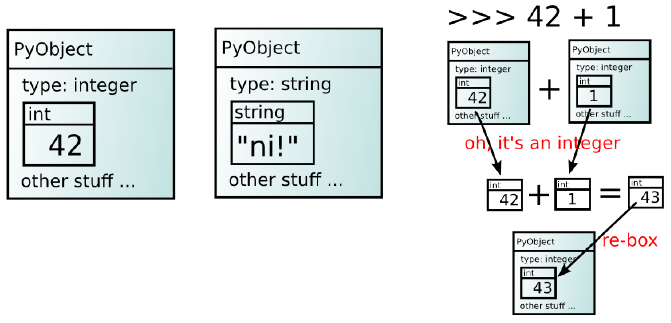

```python
Image(filename="box.png")
```

When the code executes, the Python interpreter decides what properties the variable may have depending *on context*. The following C code:

```
int i,j,k;
i = 2;
j = 2;
k = i*j;
return k
```

means the CPU will use approximately seven cycles.

The Python equivalent:

```
i = 2
j = 2
k = i*j
return k
```

involves the following operations on the **PyObject** (see below) C structures:

- creating the objects i, j and k
- assigning the appropriate attibutes
- selecting the method for the '*' operator
- calculating the result and the appropriate type for k

and each of these operations means that the interpreter creates or uses something like that:

```
typedef struct _object {
_PyObject_HEAD_EXTRA
Py_ssize_t ob_refcnt;
struct _typeobject *ob_type;
} PyObject;
```

### Bytecode

From Wikipedia:

Bytecode, also known as p-code (portable code), is a form of instruction set designed for efficient execution by a software interpreter. Unlike human-readable source code, bytecodes are compact numeric codes, constants, and references (normally numeric addresses) which encode the result of parsing and semantic analysis of things like type, scope, and nesting depths of program objects. They therefore allow much better performance than direct interpretation of source code.

### Interpreted language

Again, from Wikipedia, an interpreter may be a program that either

1. executes the source code directly
2. translates source code into some efficient intermediate representation (code) and immediately executes this
3. explicitly executes stored precompiled code made by a compiler which is part of the interpreter system

Note that, in principle, almost any language can be *compiled* or *interpreted*, it depends on whether you have (or write) a compiler program or an interpreter one. What does the **python** (using CPython on Linux) command do when you execute `python somescript.py` ?

```python
%%writefile hello_mod.py
def hello():
	print("Hello, World!")
```

```
Writing hello_mod.py
```

```python
%%writefile hello_script.py
import hello_mod

hello_mod.hello()

quit()
```

```
Writing hello_script.py
```

```python
!python3 ./hello_script.py
```

```
Hello, World!
```

```python
!ls */*.pyc
```

```
__pycache__/hello_mod.cpython-35.pyc
```

```python
!head __pycache__/*.pyc
```

```
Hello, World!)Úprint©rrúD/home/g.mancini/Dropbox/teach/calcolo_2018/05_Basic_Opt/hello_mod.pyÚhellosrN)rrrrrÚ<module>s
```

the **.pyc** is a *bytecode*, so python is in case 2 above. The Python interpreter loads .pyc files before .py files, so if they're present, it can save some time by not having to re-compile the Python source code.

*But how this affects execution speed?*

Compared to an interpreter, a good compiler can look ahead and optimize the code (remove redundant operation, unrolling small loops). This may be guided by user selected switches, yielding a significant speed-up. However, compilation may be a difficult task by itself, requiring knowledge of the platform and compiler being used.

The **dis** module allows you to dissassemble your Python bytecode.

### Locality

One of the key features of Numpy is the locality of data that allows to access to rows and columns as C (or Fortran) plus the decoration that make possible all the fancy stuff. The values in the array are **contiguous** and have a common size.

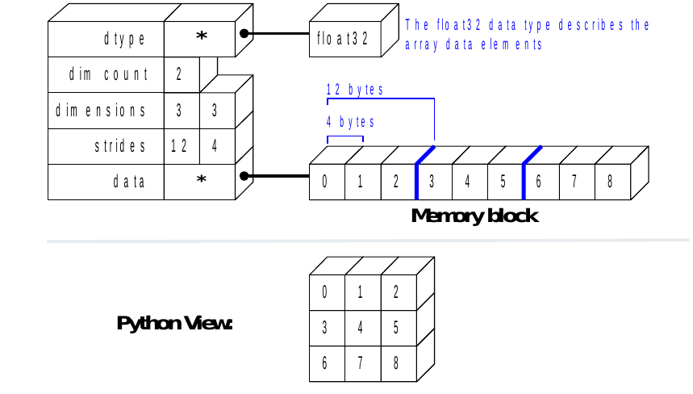

```python
Image(filename="array.png")
```

On the opposite, a list object in CPython is represented by the following C structure. **ob_item** is an array of pointers to the list elements. **allocated** is the number of slots allocated in memory

```
typedef struct {
    PyObject_VAR_HEAD
    PyObject **ob_item;
    Py_ssize_t allocated;
} PyListObject;
```

each element in the Python list is found by a pointer to a buffer of pointers, each of which points to a Python object which encapsulates its own data. Thus, operations like *append* or *pop* are cheap but running over all the elements in the list can be costly since it involves a great deal of referencing operations and (likely) a lot of copies to and from the memory.